# Problem set 4 - CSCI E-88b Spring 2020

## Due date: Friday, May 8 2020, 10pm EST.

Please write down the last 5 digits of your Harvard ID: 70196

Please write down the URL of your Renku project: https://renkulab.io/projects/stephen.t.knapp14/problem4

Please indicate who you may have worked with on this problem and which section you worked with someone on. If you did not work with anyone then you can leave this blank: xxxxx

## This problem set corresponds to 1/6 of your final grade. It is graded out of 10.

Question 4.0: 0pt

Question 4.1: 2pts

Question 4.2: 2pts

Question 4.3: 4pts

Question 4.4: 2pts

## Question 4.0: Keep it private!

### If your problem set is not private, your grade will be 0/10.

**Question**: Please confirm that your project is private. You can edit the markdown cell from `[ ]` to `[x]` to check a box.

**Your answer (4.0):**

- [X] Yes, my project is private.
- [ ] No, my project is not private.

## Objectives

This problem set aims at giving you a sense of how we can use create HPC workflows using several big data tools. We are going to use the Harvard Cannon cluster to geo-process large amounts of data.

## Question 4.1: Interpret geo-processing code

We want to use the North American Regional Estimates of PM2.5 from http://fizz.phys.dal.ca/~atmos/martin/?page_id=140. Annual data is available for years 2000-2018 at the grid level.

```r
library(raster)
library(maptools)
library(proj4)
library(ncdf4)
```

```r
grid_file <- "../data/pm25/pm2000.nc"
grids <- raster(grid_file)
```

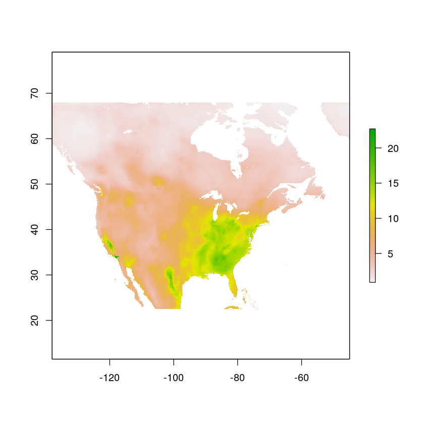

```r
plot(grids) # just to get a sense of the data; not needed in Question 4.2
```

```r
poly_file <- "../data/tl_2010_us_state00/tl_2010_us_state00.shp"
poly <- shapefile(poly_file)
```

```r
proj4string(grids) <- proj4string(poly)
```

This step is going to require time (~15 min):

```r
ex <- extract(grids, poly, fun = mean, na.rm = TRUE, df = TRUE)
```

```r
result <- data.frame(ex)
result$State <- poly@data$NAME00
result$ID <- NULL
```

```r
names(result) <- c("PM25_2000","State")
result
```

A data.frame: 52 × 2

| PM25_2000 <dbl> | State <chr> |
| --- | --- |
| 9.072290 | New York |
| 12.341906 | West Virginia |
| 10.025059 | Rhode Island |
| NA | Puerto Rico |
| 8.188588 | Michigan |
| 13.711564 | Tennessee |
| 5.822106 | North Dakota |
| 7.733470 | California |
| 5.304781 | Nevada |
| 15.240623 | Georgia |
| 6.257286 | South Dakota |
| 5.479989 | Utah |
| 14.082421 | South Carolina |
| 1.752601 | Alaska |
| 12.959899 | Mississippi |
| 12.682241 | Arkansas |
| 10.511416 | Missouri |
| 11.760442 | Pennsylvania |
| 9.926818 | Iowa |
| 8.320212 | Kansas |
| 5.744527 | Colorado |
| 11.752861 | Florida |
| 12.822392 | New Jersey |
| 13.860695 | Delaware |
| 5.684786 | Montana |
| 6.558850 | Washington |
| 10.777092 | Connecticut |
| 14.194189 | Indiana |
| 9.570973 | Massachusetts |
| 12.485055 | Louisiana |
| 15.361901 | Alabama |
| 13.452344 | North Carolina |
| 13.507160 | Maryland |
| 13.660611 | Kentucky |
| 6.416755 | Idaho |
| 5.093982 | Wyoming |
| 7.169713 | Nebraska |
| NA | Hawaii |
| 7.240149 | New Hampshire |
| 5.278993 | Oregon |
| 13.998440 | Ohio |
| 9.213114 | Oklahoma |
| 6.282766 | Arizona |
| 8.765978 | Wisconsin |
| 7.363702 | Minnesota |
| 14.925137 | District of Columbia |
| 12.496229 | Virginia |
| 9.433195 | Texas |
| 5.443897 | New Mexico |
| 7.120827 | Vermont |
| 5.385208 | Maine |
| 12.809383 | Illinois |

**Question (4.1):** What are the objectives of the code chunks of Question 4.1? (Please limit your answer to one or two sentences.)

**Your answer (4.1):** Chunk 1: This chunk loads several libraries into our working images and makes availble the function in those libraries/packages for us to use that do not exist in the base R. Raster is for, "reading, writing, manipulating, analyzing and modeling of gridded spatial data." It can also process large datasets. Maptools provides a "set of tools for manipulating geographic data." Proj4, "allows transformation of geographic coordinates from one projection and/or datum to another." Finally, ncdf4 is for utilizing netCDF files, "which are binary data files that are portable across platforms and include metadata information in addition to the data sets."

Chunk 2: The first line assigns the file path for a datafile to the variable "grid_file". The second line uses the raster command on the grid_file variable which creates a RasterLayer object that with parameters that match the .nc file but MAY or MAY NOT include any actual data. The RasterLayer object was assigned the name "grids"

Chunk 3: The plot command is used on the "grids" object to generate a heatmap of North America. Now we have a better idea of the data we are working with and we know that the RasterLayer created in chunk 2 does indeed include pixel data that was used to generate the heatmap.

Chunk 4: The first line assigns a shape (.shp) file's path to the object named, "poly_file." The second line uses the shapefile command to read in the poly_file object which contains spatial data. Shapefiles consist of, at a minimum, four sub-files that contains data on attributes, geometry, index and the coordinate reference system. This particular shape file contains 5 files.

Chunk 5: The proj4string() function is used on the poly object to identify its coordinate reference systems. The identified coordinate reference systems is then applied as the same coordinate reference system for the grids object. Functionally, this allows the data in grids to be partitioned into US states.

Chunk 6: The extract command takes the data in the grids object and provides the mean values of those data in the groupings defined in the US state-shaped polygons contained in the poly object. If the function finds any NA values it will remove them before the calculation. The output of the means by state will be in a R dataframe. This dataframe is assigned the name "ex."

Chunk 7: The first line takes the object "ex" which is already a dataframe (because df=TRUE for the last command in chunk 6) and turns it into a dataframe again named "result". The second line takes the names of the US states contained in poly object, creates a new column on the results dataframe and inserts those state names that correspond to the means. The third line remove an index column in the results dataframe that is no longer needed now that the states names are in the dataframe.

Chunk 8: The first line names the columns of the results dataframe. The second line prints the dataframe "results".

## Question 4.2: Upload data to Harvard Cannon

**Question (4.2):** We want to run the compuations of Question 4.1 on the cluster. PM2.5 data is already available on Harvard Cannon, but the shapefile is not. So the first step is to copy folder `data/tl_2010_us_state00` to your home folder (or a folder of your choice in home home folder) on the cluster. Describe the steps and commands that we are using.

**Your answer (4.2):**

Step 1: Copy contents of folder data/tl_2010_us_stat00 to the cluster home folder using the following line of code entered into a Renku terminal (not on the Harvard Cannon terminal):

$ scp -r ./data/tl_2010_us_state00 e88bu2044@login.rc.fas.harvard.edu:~/

Breakdown of the command:

```
scp: is the secure copy command

-r: is the recursive switch that let's the command know I want to copy everything in the "from" directory

./data/tl_2010_us_state00: is the location of the directory folder on Renku that I want to copy the contents of

e88bu2044@login.rc.fas.harvard.edu:~/: tells the command I want to take the copied file and put it in my home directory on Harvard Cannon
```

Step 2: confirm the files have been copies to my home on Cannon:

(on a terminal on the Cannon log-in node): $ ls

```
                                        Documents  singularity  tl_2010_us_state00
```

This shows the directory has been successfully copied

## Question 4.3: Run geo-processing code at scale on Harvard Cannon

Run the geo-processing for years 2000-2018 as a Harvard Cannon `sbatch` job.

PM2.5 data is available in folder `/n/holyscratch01/e88b/problem4/data/pm25`.

Use `singularity` with Rocker geospatial and gather the geo-processing results for years 2000-2018 as a CSV file `result_linkage.csv` with columns `State`, `PM25_2000`, ..., `PM25_2018`, sorted in alphabetical order of `State`.

**Question (4.3):** Please provide all the `sbatch`-related material you submitted.

**Your answer (4.3):**

Step 1: I wrote 4 scripts (2 .batch and .R pairs). The first pair is for extracting the data for each year. The second pair is for aggregating the data into 1 .csv file.

```
problem4.batch file:

#!/bin/bash
#SBATCH -p shared
#SBATCH --mem 8g
#SBATCH -t 0-6:00
#SBATCH -c 5
#SBATCH -a 2000-2018      # Array of 19 jobs, with ids 1, 2, ...19
#SBATCH -o out_%A_%a.out  # starndard output
#SBATCH -e err_%A_%a.out  # standard error

## EXECUTE CODE ##
singularity exec geospatial_latest.sif R CMD BATCH problem4rcode.R script_$SLURM_ARRAY_TASK_ID

/// END OF FILE ///

problem4rcode.R file:

#load required libraries
library(raster)
library(maptools)
library(proj4)
library(ncdf4)

#define the function to analyze each year
one.year <- function(year){

    #create grid from data
    grid_file <- paste0("/n/holyscratch01/e88b/problem4/data/pm25/pm",year,".nc")
    grids <- raster(grid_file)

    #use shape file to overlay state boundaries
    poly_file <- "~/tl_2010_us_state00/tl_2010_us_state00.shp"
    poly <- shapefile(poly_file)

    #map state boundries to grid data
    proj4string(grids) <- proj4string(poly)

    #take means by state
    ex <- extract(grids, poly, fun = mean, na.rm = TRUE, df = TRUE)

    #convert means to a data frame and add state names from the shape file
    result <- data.frame(ex)
    result$State <- poly@data$NAME00

    #drop the ID column and assign column headers
    result$ID <- NULL
    names(result) <- c(paste0("PM25_",year), "State")

    #function returns the analyzed data by state in a data frame
    return(result)
}

#set the year for this run
id <- as.numeric(Sys.getenv("SLURM_ARRAY_TASK_ID"))

#run the function
csv.file.name <- paste0("result_linkage_",id,".csv")
write.csv(one.year(id), csv.file.name, row.names = FALSE)

/// END OF FILE ///

aggregate.batch file:

#!/bin/bash
#SBATCH -p shared
#SBATCH --mem 8g
#SBATCH -t 0-6:00
#SBATCH -c 5
#SBATCH -o out_%A_%a.out  # standard output
#SBATCH -e err_%A_%a.out  # standard error

## EXECUTE CODE ##
singularity exec geospatial_latest.sif R CMD BATCH aggregate.R script_aggregate

/// END OF FILE ///

aggregate.R file:

#file for aggregating yearly data

#all years considered
years <- seq(2000,2018)

#create list to store results for each year
aggregated.results <- vector(mode="list", length = length(years))

#initialize loop counter
i <- 1

#for loop to create yearly data frames
for (y in years){

    #generate the file name to open
    csv.file.name <- paste0("result_linkage_",y,".csv")

    #read the csv file and assign it to the master list
    aggregated.results[[i]] <- read.csv(csv.file.name)

    #advance counter
    i <- i + 1
}

#condense the results into 1 data frame which also auto sorts it by State
condensed.results <- Reduce(function(x,y) merge(x = x, y = y, by = "State"), aggregated.results)

#create a csv file from the condensed data
write.csv(condensed.results, file = "result_linkage.csv", row.names = FALSE)

/// END OF FILE ///
```

Step 2: Next I copied the 4 files to my home directory on Cannon:

```
scp ./problem_set/problem4rcode.R e88bu2044@login.rc.fas.harvard.edu:~/problem4
scp ./problem_set/problem4.batch e88bu2044@login.rc.fas.harvard.edu:~/problem4
scp ./problem_set/aggregate.R e88bu2044@login.rc.fas.harvard.edu:~/problem4
scp ./problem_set/aggregate.batch e88bu2044@login.rc.fas.harvard.edu:~/problem4
```

Step 3: Open a compute node:

```
Access 1 compute node with 4g memory, for 6 hours on the class's shared partition:
[e88bu2044@boslogin02 problem4]$ srun -p shared -n 1 -t 00-6:00 --pty --mem=4000 bash
```

Step 4: Create a batch job array

```
[e88bu2044@holy7c18412 problem4]$ sbatch problem4.batch
This creates .csv files for every year by splitting each year into its own job in the array
Error files were all empty and my directory contained all the correct files after the job array was completed
```

Step 5: Aggregate the data

```
[e88bu2044@holy7c18412 problem4]$ sbatch aggregate.batch
This reads in all the yearly csv files and aggregates them into one csv file
```

## Question 4.4: Download data from Harvard Cannon

Copy `result_linkage.csv` to your `data/` folder in Renku.

**Question (4.4):** You have generated `result_linkage.csv` file on Harvard Cannon in Question 4.3. Now, the next and last step is to copy this file to your `data/` folder in your Renku `problem3` folder. Describe the steps and commands that we are using and make sure your run the code snippet below.

**Your answer (4.4):**

I entered the following from a Renku terminal (while a SSH connection was open):

```
$ scp e88bu2044@login.rc.fas.harvard.edu:~/problem4/result_linkage.csv ./data

Breakdown of the command elements:
    scp: secure copy command
    e88bu2044@login.rc.fas.harvard.edu: username and server where the file is located
    ~/problem4/result_linkage.csv: location of the file on the server
    ./data: location where I am copying to
```

Make sure you run the following code snippet:

```r
d <- read.csv("../data/result_linkage.csv")
d
```

A data.frame: 52 × 20

| State <fct> | PM25_2000 <dbl> | PM25_2001 <dbl> | PM25_2002 <dbl> | PM25_2003 <dbl> | PM25_2004 <dbl> | PM25_2005 <dbl> | PM25_2006 <dbl> | PM25_2007 <dbl> | PM25_2008 <dbl> | PM25_2009 <dbl> | PM25_2010 <dbl> | PM25_2011 <dbl> | PM25_2012 <dbl> | PM25_2013 <dbl> | PM25_2014 <dbl> | PM25_2015 <dbl> | PM25_2016 <dbl> | PM25_2017 <dbl> | PM25_2018 <dbl> |
| --- | --- | --- | --- | --- | --- | --- | --- | --- | --- | --- | --- | --- | --- | --- | --- | --- | --- | --- | --- |
| Alabama | 15.347304 | 12.882067 | 12.184880 | 12.965523 | 12.613791 | 13.510309 | 12.810725 | 13.253317 | 10.865232 | 9.707536 | 10.636200 | 10.031425 | 9.391572 | 8.465170 | 8.899203 | 8.088136 | 8.060918 | 8.239195 | 8.171189 |
| Alaska | 1.163441 | 1.436871 | 1.503111 | 1.561109 | 3.068461 | 2.123017 | 1.800628 | 1.453905 | 2.043083 | 3.397013 | 2.369219 | 1.584036 | 1.596347 | 2.009483 | 1.398118 | 1.495608 | 1.602988 | 1.370518 | 1.798716 |
| Arizona | 5.689456 | 5.993380 | 5.117804 | 5.184043 | 3.938154 | 4.312784 | 4.530332 | 5.628298 | 4.789076 | 4.489540 | 3.814517 | 5.112732 | 4.800733 | 4.998942 | 5.142187 | 4.558616 | 4.330584 | 4.237862 | 4.245860 |
| Arkansas | 12.217614 | 10.674957 | 9.675823 | 10.481907 | 9.085027 | 11.124031 | 9.643626 | 10.445435 | 8.998145 | 8.075637 | 9.497658 | 9.301901 | 7.652951 | 7.747413 | 7.559343 | 7.216011 | 6.407877 | 7.113078 | 7.571720 |
| California | 7.235699 | 7.365023 | 7.532225 | 6.398249 | 6.003756 | 5.925828 | 6.118509 | 7.454718 | 7.261316 | 6.219630 | 5.389099 | 6.522994 | 6.367460 | 6.614856 | 6.167703 | 6.265551 | 5.382421 | 6.829416 | 8.279960 |
| Colorado | 5.130564 | 5.214317 | 5.001115 | 4.398830 | 4.030641 | 3.966444 | 3.918576 | 4.513340 | 4.199499 | 3.774940 | 3.709943 | 4.120413 | 4.201538 | 4.066183 | 3.309163 | 3.091565 | 2.731785 | 3.229304 | 3.788489 |
| Connecticut | 10.639409 | 11.514075 | 10.585961 | 10.430752 | 9.432230 | 9.420129 | 8.167784 | 9.443674 | 8.709760 | 7.167883 | 6.459410 | 7.134628 | 6.482835 | 7.112575 | 6.576455 | 6.501351 | 5.106132 | 5.399682 | 6.296570 |
| Delaware | 14.472174 | 13.955687 | 13.521107 | 13.271980 | 12.842338 | 13.533627 | 12.388309 | 12.464433 | 11.680215 | 10.264310 | 10.915183 | 10.060730 | 9.618233 | 8.824458 | 9.438847 | 9.474855 | 8.514530 | 8.534227 | 7.984694 |
| District of Columbia | 16.108197 | 15.863388 | 15.031694 | 14.154098 | 14.377596 | 14.980328 | 13.393989 | 13.521311 | 12.028962 | 10.400000 | 11.142623 | 10.867213 | 10.423497 | 9.425683 | 9.543169 | 9.821311 | 8.806557 | 8.865027 | 8.565574 |
| Florida | 11.992685 | 10.026597 | 9.427851 | 9.660862 | 10.583474 | 10.565889 | 10.101790 | 10.253119 | 8.831457 | 8.227842 | 8.771751 | 8.632780 | 7.790277 | 7.013290 | 7.463267 | 6.967170 | 6.960475 | 6.759004 | 6.606873 |
| Georgia | 15.298356 | 12.611452 | 11.931417 | 11.892146 | 12.733371 | 12.953578 | 12.571776 | 12.737533 | 11.038497 | 9.595375 | 10.575117 | 10.313986 | 8.916730 | 7.947075 | 8.565827 | 7.476638 | 8.192414 | 8.042266 | 7.617720 |
| Hawaii | NA | NA | NA | NA | NA | NA | NA | NA | NA | NA | NA | NA | NA | NA | NA | NA | NA | NA | NA |
| Idaho | 5.310285 | 3.937207 | 3.868958 | 3.854266 | 3.878750 | 4.185322 | 4.255912 | 4.934222 | 3.864722 | 3.511235 | 3.252498 | 3.594878 | 5.966468 | 4.371621 | 3.180437 | 4.305926 | 2.940999 | 6.931552 | 4.533589 |
| Illinois | 11.669739 | 12.038823 | 10.994932 | 11.000167 | 9.621084 | 12.672150 | 10.004979 | 11.523249 | 10.396497 | 9.854391 | 10.718277 | 9.169148 | 7.969472 | 8.197700 | 9.103812 | 8.014186 | 7.260919 | 7.598450 | 8.698269 |
| Indiana | 13.340957 | 13.176687 | 12.819609 | 12.756080 | 11.025661 | 14.264042 | 11.674200 | 12.823672 | 10.842832 | 10.351406 | 11.577171 | 10.562460 | 9.323427 | 9.487869 | 10.346012 | 8.725160 | 8.058459 | 8.177143 | 8.801389 |
| Iowa | 8.699789 | 8.915940 | 8.712073 | 9.830617 | 8.358763 | 10.203216 | 8.481950 | 9.388200 | 8.359071 | 8.758066 | 8.898259 | 8.545785 | 8.086903 | 7.818458 | 7.313639 | 6.980961 | 5.849142 | 6.775088 | 7.033096 |
| Kansas | 6.979502 | 6.981876 | 6.685182 | 6.728385 | 6.063742 | 7.044378 | 6.277794 | 7.071324 | 6.582228 | 6.563730 | 6.083430 | 6.669981 | 6.598754 | 5.963834 | 5.952876 | 5.294605 | 4.781287 | 5.477956 | 5.998017 |
| Kentucky | 13.590258 | 13.125039 | 11.725765 | 11.916318 | 11.197411 | 13.600271 | 11.870399 | 12.259814 | 9.704291 | 8.779851 | 9.849139 | 9.510383 | 9.006903 | 8.195428 | 8.318525 | 7.463707 | 7.617809 | 6.902139 | 7.461659 |
| Louisiana | 12.069336 | 10.422241 | 9.439268 | 10.746674 | 9.771054 | 11.827060 | 10.845474 | 10.543334 | 9.239259 | 8.153810 | 9.266817 | 9.122289 | 8.562337 | 7.970493 | 7.775779 | 7.681622 | 7.352629 | 8.137586 | 8.799813 |
| Maine | 4.344670 | 4.891472 | 5.057838 | 5.760975 | 4.751804 | 5.255351 | 4.397265 | 4.323193 | 4.317743 | 3.929326 | 3.767753 | 4.329903 | 3.411041 | 3.973423 | 3.894745 | 3.708262 | 2.953595 | 3.610887 | 3.483354 |
| Maryland | 13.698000 | 13.355853 | 12.745050 | 12.331229 | 12.490721 | 13.156707 | 11.659096 | 12.055023 | 10.967813 | 9.495899 | 10.436615 | 10.002469 | 9.546922 | 8.521565 | 9.013040 | 8.847831 | 7.802094 | 7.549613 | 7.485745 |
| Massachusetts | 8.858266 | 9.410097 | 8.793990 | 8.859371 | 8.287843 | 8.060651 | 7.182392 | 8.572141 | 7.957169 | 6.716836 | 6.101355 | 6.883777 | 6.044549 | 6.241029 | 6.106598 | 5.863141 | 4.553699 | 5.120048 | 5.742985 |
| Michigan | 7.036112 | 7.677911 | 7.882109 | 8.150643 | 7.275905 | 8.870612 | 7.403912 | 7.642585 | 7.287858 | 6.448293 | 5.843897 | 5.761447 | 6.104570 | 5.621589 | 6.309692 | 5.428374 | 4.921310 | 5.480541 | 6.062763 |
| Minnesota | 6.211781 | 6.086538 | 5.800740 | 6.782576 | 6.665649 | 6.752646 | 6.007239 | 6.672554 | 6.898464 | 6.516872 | 6.217937 | 5.207970 | 5.857721 | 5.333914 | 4.801693 | 4.736690 | 3.707289 | 5.193646 | 5.765812 |
| Mississippi | 12.518602 | 10.927095 | 10.406771 | 11.130582 | 10.633436 | 11.996163 | 11.216373 | 11.290191 | 9.683604 | 8.365016 | 9.560253 | 9.167638 | 8.977364 | 7.852173 | 8.014861 | 7.203227 | 6.718613 | 7.030648 | 7.544092 |
| Missouri | 9.645852 | 9.473839 | 9.400547 | 9.595661 | 8.090892 | 10.505908 | 8.613005 | 9.374661 | 8.468166 | 7.605322 | 8.351802 | 8.289650 | 6.607262 | 7.130389 | 6.836599 | 6.540911 | 5.496270 | 6.282809 | 6.684710 |
| Montana | 4.517315 | 3.570535 | 3.165464 | 3.985604 | 2.941988 | 3.128447 | 3.648117 | 4.814044 | 3.407712 | 2.900950 | 3.141250 | 3.226778 | 4.507768 | 3.270824 | 3.107388 | 4.126302 | 2.403689 | 6.370270 | 4.428019 |
| Nebraska | 6.018922 | 5.496944 | 5.299472 | 5.434019 | 4.884213 | 5.381013 | 4.850529 | 5.779047 | 5.143366 | 4.913190 | 5.382538 | 5.025489 | 5.802566 | 4.919690 | 4.342467 | 4.262958 | 3.332886 | 4.219289 | 4.734813 |
| Nevada | 4.592638 | 4.946056 | 3.854972 | 3.802235 | 3.694125 | 4.073471 | 3.778746 | 4.638743 | 4.466094 | 3.704790 | 3.612037 | 3.920908 | 4.315569 | 4.750450 | 3.605612 | 4.333420 | 3.446824 | 4.235970 | 5.231961 |
| New Hampshire | 6.030525 | 6.807319 | 6.760655 | 7.202446 | 6.300391 | 6.344159 | 5.541005 | 6.253414 | 5.747949 | 4.900424 | 4.751906 | 5.485607 | 4.422025 | 4.871623 | 4.833853 | 4.482755 | 3.304613 | 4.342971 | 4.040886 |
| New Jersey | 13.977770 | 13.596591 | 12.438971 | 12.856051 | 11.750664 | 12.751560 | 11.009947 | 11.507509 | 10.874250 | 9.064261 | 9.051263 | 8.868580 | 8.203957 | 8.161888 | 8.305707 | 8.089259 | 7.680055 | 7.264419 | 7.089830 |
| New Mexico | 4.837870 | 5.011119 | 4.456524 | 4.376730 | 3.465059 | 3.866692 | 3.670877 | 4.065435 | 4.136649 | 3.664514 | 3.522133 | 4.604006 | 3.718656 | 4.020774 | 3.483762 | 3.216058 | 3.022161 | 3.059841 | 3.194294 |
| New York | 8.584933 | 8.905972 | 8.817709 | 9.081832 | 7.805046 | 8.767291 | 7.183392 | 7.731118 | 7.285639 | 6.160572 | 6.126159 | 6.330409 | 5.833016 | 6.075722 | 6.021889 | 5.896977 | 4.625791 | 5.707678 | 5.810624 |
| North Carolina | 13.190457 | 12.060941 | 11.479315 | 11.107806 | 11.936535 | 12.296690 | 12.203408 | 11.786436 | 10.773078 | 8.555797 | 9.307074 | 8.875029 | 8.209519 | 7.377087 | 7.920101 | 6.899151 | 6.937012 | 6.700364 | 6.252703 |
| North Dakota | 5.139933 | 4.318172 | 3.931727 | 4.476046 | 4.118152 | 4.485981 | 4.419991 | 4.696439 | 4.392779 | 4.213053 | 5.190858 | 4.136631 | 4.985468 | 4.270121 | 3.829310 | 4.336700 | 3.025736 | 4.670448 | 5.262941 |
| Ohio | 13.254557 | 12.922059 | 12.938014 | 12.900991 | 11.815539 | 13.443589 | 10.991974 | 12.317277 | 10.618599 | 9.688513 | 10.510296 | 9.705464 | 8.636926 | 8.806421 | 9.195151 | 8.162390 | 7.224730 | 7.602291 | 7.741085 |
| Oklahoma | 8.027203 | 7.948275 | 7.336305 | 8.131242 | 7.582253 | 8.952467 | 7.327964 | 8.251136 | 7.623424 | 7.636270 | 7.474295 | 8.327422 | 7.423498 | 7.280501 | 6.897694 | 6.298554 | 5.818986 | 6.415995 | 6.605024 |
| Oregon | 3.302825 | 3.180348 | 3.580155 | 3.221450 | 3.530344 | 3.485656 | 3.645229 | 3.621429 | 4.110627 | 3.700995 | 2.722526 | 3.236064 | 3.905921 | 3.763427 | 3.030223 | 4.044758 | 1.889954 | 5.924183 | 5.311741 |
| Pennsylvania | 11.823097 | 12.001746 | 11.275934 | 11.330120 | 10.936986 | 11.423820 | 9.636918 | 10.360929 | 9.415448 | 8.363397 | 8.597867 | 8.545592 | 8.155149 | 8.302960 | 7.738736 | 7.665614 | 6.737445 | 6.690048 | 6.293150 |
| Puerto Rico | NA | NA | NA | NA | NA | NA | NA | NA | NA | NA | NA | NA | NA | NA | NA | NA | NA | NA | NA |
| Rhode Island | 9.621045 | 10.530667 | 9.225708 | 9.471576 | 8.805519 | 8.730579 | 7.820691 | 8.759298 | 8.266293 | 6.752597 | 6.436364 | 7.019156 | 6.484593 | 6.221045 | 5.532202 | 6.332025 | 4.862603 | 5.575354 | 6.453424 |
| South Carolina | 14.522920 | 12.323125 | 11.480108 | 11.386770 | 12.230113 | 13.174238 | 12.923847 | 12.449897 | 11.137897 | 9.435940 | 10.490611 | 9.945116 | 9.037151 | 7.868473 | 8.357747 | 7.230829 | 8.061507 | 7.464568 | 7.088742 |
| South Dakota | 5.392872 | 5.184528 | 4.469669 | 4.791280 | 4.551043 | 5.008997 | 4.847093 | 5.322167 | 4.834568 | 4.657553 | 5.127387 | 4.404596 | 5.561601 | 4.645025 | 4.233466 | 4.567251 | 3.010704 | 4.213630 | 4.528247 |
| Tennessee | 13.883759 | 12.363131 | 11.579901 | 11.684802 | 11.628637 | 12.944490 | 12.082551 | 12.079308 | 9.661992 | 8.780817 | 9.709744 | 9.754572 | 8.836659 | 8.054723 | 8.144854 | 7.140841 | 7.476169 | 6.969238 | 7.129005 |
| Texas | 8.570381 | 7.902247 | 7.335994 | 7.935208 | 6.907435 | 8.016654 | 7.236649 | 7.757435 | 7.540848 | 6.898631 | 6.980116 | 7.707123 | 7.184391 | 6.963047 | 6.476363 | 6.586598 | 6.074140 | 6.206067 | 6.347704 |
| Utah | 4.961843 | 5.826140 | 4.519672 | 4.394711 | 4.645198 | 4.531372 | 4.085534 | 4.963067 | 4.343243 | 4.019723 | 3.947784 | 3.971458 | 4.274129 | 4.976938 | 3.565612 | 3.478469 | 2.850263 | 2.958596 | 3.334350 |
| Vermont | 5.793251 | 6.335894 | 7.240539 | 7.491725 | 6.608264 | 6.944198 | 5.665410 | 6.126447 | 5.598324 | 4.922245 | 5.016789 | 5.774614 | 4.679102 | 4.965339 | 5.094258 | 4.770705 | 3.575886 | 4.756174 | 4.371052 |
| Virginia | 12.539216 | 11.834776 | 10.686814 | 10.565359 | 11.013120 | 11.652073 | 10.593924 | 11.274978 | 9.583055 | 7.573068 | 8.709832 | 7.987412 | 7.631563 | 6.801374 | 7.115126 | 6.661484 | 5.961319 | 5.498241 | 5.403960 |
| Washington | 4.651522 | 4.364985 | 4.354338 | 4.591031 | 4.681852 | 4.043883 | 4.437848 | 3.849688 | 3.903799 | 4.085540 | 3.138857 | 3.521400 | 3.654864 | 3.889079 | 3.286765 | 4.698963 | 2.316720 | 6.493495 | 6.294994 |
| West Virginia | 12.254838 | 12.231564 | 10.469770 | 10.716321 | 11.241424 | 12.200484 | 10.158074 | 11.251100 | 9.158877 | 7.269151 | 8.656710 | 8.326110 | 7.680567 | 6.981416 | 6.622020 | 6.382873 | 5.657309 | 4.784531 | 5.030084 |
| Wisconsin | 7.624934 | 8.054028 | 8.071813 | 8.647736 | 7.496344 | 8.397782 | 7.117699 | 7.942171 | 8.358066 | 7.208743 | 6.263902 | 6.133281 | 6.470986 | 6.340375 | 5.934128 | 5.067686 | 4.784548 | 5.512337 | 6.487407 |
| Wyoming | 4.569579 | 4.653051 | 3.833058 | 3.967193 | 3.980457 | 4.154461 | 4.114243 | 4.488533 | 3.986310 | 3.131120 | 3.372928 | 3.305246 | 4.590811 | 3.640066 | 3.038365 | 3.427518 | 2.558877 | 3.742256 | 3.315568 |

## Self-assessment (not graded)

**Questions**

1. What do you think I was hoping for you to learn through this homework?
2. Did you find anything particularly challenging?

**Your answer**

1. How to use a cluster, rocker, scripts, run job arrays, and how to aggregate "big data".
2. Aggregating the files was very challenging. I had to totally rethink the way I generally program loops and get outputs from functions.

# Submitting your work

To submit the problem set, export the notebook to HTML and upload the file to Canvas.

[`File` -> `Export Notebook As...` ->`Export Notebook to HTML`]